# Tugas 1 IF2122 Probabilitas dan Statistika

# Menentukan Distribusi Peluang

### Batas Pengumpulan: 10 Maret 2018 pukul 21.00

### Arsip Pengumpulan:

File zip yang berisi file .ipynb dan .pdf

### Deskripsi Tugas

Pada tugas ini mahasiswa diminta untuk mengerjakan 5 soal terkait dengan distribusi peluang. Untuk menjawab soal, mahasiswa diharuskan membuat program bahasa R yang ditulis pada Jupyter Notebook.

#### Soal 1.

Data: tinggimhs.csv

Institut Pertanian Indonesia (IPI) memiliki 10000 mahasiswa jurusan sastra teknik informatika. Suatu hari rektor IPI mendengar berita bahwa semakin tinggi seseorang, semakin besar kemungkinan orang tersebut akan sukses di kemudian hari. Oleh karena itu, IPI ingin menganalisis distribusi tinggi mahasiswa-mahasiswanya untuk memenuhi rasa penasaran apakah berita itu benar atau tidak. Sebagai seorang (calon) ahli statistika, Anda diminta oleh rektor IPI untuk:

1. Menulis deskripsi statisktika (Descriptive Statistics) dari data tinggi mahasiswa, minimal terdiri dari mean, median, modus, standar deviasi, variansi, range, nilai minimum dan maksimum.
2. Menentukan distribusi yang *paling sesuai* dari data tinggi mahasiswa. Jelaskan alasan mengapa distribusi tersebut dipilih.
3. Membuat plot distribusi yang dipilih beserta plot distribusi kumulatifnya.
4. Apabila suatu hari IPI menerima 1000 mahasiswa, tentukan ekspektasi jumlah mahasiswa yang diterima dengan tinggi: a. dibawah 150.00cm b. diatas 200.00cm
5. Apabila suatu hari IPI menerima 500 mahasiswa, tentukan ekspektasi jumlah mahasiswa yang diterima dengan tinggi: a. diantara 160.00cm dan 190.00cm inklusif b. sama dengan 170.00cm

#### Soal 2.

Data: commentlength.csv

Suatu hari rektor IPI menetapkan peraturan baru yaitu setiap mahasiswa tidak diperbolehkan berada di area kampus diatas pukul 19.00 WITA. Hal ini mendapatkan perhatian negatif dari mahasiswanya karena banyak mahasiswa yang sering beraktivitas di kampus pada malam hari. Oleh karena itu, rektor IPI membuka forum online dimana seluruh mahasiswa dapat memberi komentar (kritik/saran) mengenai peraturan tersebut. Komentar yang diberika mahasiswa beragam; ada yang panjang dan sangat informatif, ada juga yang pendek dan hanya menyalahkan peraturan tanpa penjelasan dan solusi. Rektor IPI hanya tertarik dengan komentar yang panjang dan informatif sehingga ia meminta Anda, seorang (calon) ahli statistika, untuk membantunya menganalisis komentar-komentar mahasiswanya. Ia sudah memproses data komentar mahasiswa untuk memperoleh data panjang komentar mahasiswa dalam satuan kata (commentlength.csv) sehingga Anda bisa langsung melakukan analisis. Berikut adalah hal yang dia minta Anda lakukan:

1. Menulis deskripsi statisktika (Descriptive Statistics) dari data komentar, minimal terdiri dari mean, median, modus, standar deviasi, variansi, range, nilai minimum dan maksimum.
2. Menentukan distribusi yang *paling sesuai* dari data komentar. Jelaskan alasan mengapa distribusi tersebut dipilih.
3. Membuat plot distribusi yang dipilih beserta plot distribusi kumulatifnya.
4. Apabila hari ini IPI menerima 100 komentar dari mahasiswa, tentukan ekspektasi jumlah komentar yang panjangnya: a. dibawah 3 kata b. diatas 50 kata
5. Apabila hari ini IPI menerima 200 komentar dari mahasiswa, tentukan ekspektasi jumlah komentar yang panjangnya: a. diantara 4 dan 6 kata (inklusif) b. hanya 1 kata

#### Soal 3.

Data: ujian.csv

Kampus IPI sangat terkenal di Indonesia karena salah satu peraturannya, yaitu mahasiswa yang mendapat nilai ujian dibawah batas kelulusan boleh melakukan ujian ulang (dengan jumlah yang tak terbatas) sampai nilainya sama atau melebihi batas kelulusan (75). Apabila mahasiswa yang sudah lulus ujian merasa nilainya kurang memuaskan, ia boleh melakukan ujian ulang sampai ia merasa puas dengan nilainya. Tentunya dosen sudah menyediakan soal ujian yang berbeda untuk setiap ujian ulang sehingga mahasiswa tetap harus mempersiapkan diri. Suatu hari, seorang mahasiswa bernama X ditantang oleh temannya bernama Y untuk mengerjakan ujian matakuliah sastra teknik informatika sebanyak 200 kali! Dengan merasa semangat, X pun menerima tantangan dari temannya untuk mengerjakan ujian sebanyak 200 kali. Sebagai seorang (calon) ahli statistika, Anda penasaran tentang hasil ujian yang dilakukan X sehingga Anda melakukan analisis terhadap nilai ujian tersebut. Berikut adalah hal akan Anda lakukan:

1. Menulis deskripsi statisktika dari data ujian, beserta peluang X lulus ujian dan peluang X tidak lulus ujian matakuliah sastra teknik informatika.
2. Apabila Y menantang X lagi untuk melakukan ujian matakuliah sastra teknik informatika sebanyak 20 kali, tentukan peluang untuk kasus: a. distribusi yang *paling sesuai* untuk persoalan ini beserta alasan mengapa distribusi tersebut dipilih b. plot distribusi distribusi yang dipilih dan plot distribusi kumulatif c. minimal X lulus sebanyak 8 kali d. maksimal X tidak lulus sebanyak 10 kali
3. Apabila Y menantang X untuk melakukan ujian matakuliah sastra teknik informatika berkali-kali sampai X lulus, tentukan: a. distribusi yang *paling sesuai* untuk persoalan ini beserta alasan mengapa distribusi tersebut dipilih b. plot distribusi distribusi yang dipilih dan plot distribusi kumulatif c. peluang X lulus setelah menyelesaikan ujian ke-10 d. peluang X lulus setelah menyelesaikan ujian ke-4 atau ke-6 e. peluang X lulus apabila hanya diberi 3 kali kesempatan f. peluang X lulus setelah menyelesaikan ujian pertama

#### Soal 4.

Data: kejahatan.csv

Setelah rektor IPI mendapatkan kritik yang negatif mengenai peraturan jam malam sebelumnya, ia memutuskan untuk menarik peraturan tersebut. Akan tetapi, sebenarnya tujuan awal ia menetapkan peraturan tersebut adalah untuk mengurangi kejahatan yang terjadi pada malam hari. Untuk tetap bisa mencapai tujuan awalnya, ia mencoba berbagai cara lain seperti memasang banyak CCTV dan mempekerjakan lebih banyak satpam keamanan. Setelah tiga tahun berlalu, ia ingin tahu apakah usaha yang ia sudah lakukan sudah cukup baik. Oleh karena itu, ia menghubungi Anda, seorang ahli statistika, untuk datang dan membantu menganalisis data kejahatan 3 tahun. Anda diminta untuk:

1. Menulis deskripsi statisktika dari data kejahatan.
2. Menentukan distribusi yang *paling sesuai* untuk persoalan tersebut. Jelaskan alasan mengapa distribusi tersebut dipilih.
3. Membuat plot distribusi yang dipilih beserta plot distribusi kumulatifnya.
4. Tentukan peluang: a. tidak terjadi kejahatan selama 1 bulan (30 hari) b. maksimal terjadi 20 kejahatan selama 1 tahun
5. Selama 1 tahun, tentukan berapa kali terjadinya kejahatan apabila peluang terjadinya kejahatan tersebut sebesar 0.02634

### Lain-lain

1. Tugas dikerjakan secara individu.
2. Program dibuat dalam bahasa pemrograman R.
3. Program ditulis pada Jupyter Notebook.
4. Program harus mengandung komentar yang jelas.
5. Batas pengumpulan adalah 10 Maret 2018 pukul 21.00. *Keterlambatan akan mengurangi nilai*.
6. File yang dikumpulkan adalah notebook yang berisi hasil pekerjaan mahasiswa dalam format .pdf dan .ipynb, dizip dengan nama file **T1-IF2122-NIM.zip**.
7. Pranala pengumpulan akan dikabari oleh asisten paling lama h-2 sebelum pengumpulan.

### Referensi

1. Dokumentasi R - https://www.rdocumentation.org/
2. Project Jupyter - http://jupyter.org/
3. Walpole, dkk. 2012. *Probability and Statistics for Engineers and Scientist: ninth edition*.

**Asisten: Erick | Friska | Jehian | Johan | Steffi | Tefo**

**Dosen : Harlili | Judhi Santoso | Masayu Leylia Khodra**

```r
# Functions and vars
getMode <- function(v) {
    uniqv <- unique(v)
    uniqv[which.max(tabulate(match(v, uniqv)))]
}

ds <- data.frame(
    mean = 0,
    median = 0,
    modus = 0,
    sd = 0,
    var = 0,
    range = 0,
    max = 0,
    min = 0
)

pl <- data.frame(
    psucc = 0,
    pfail = 0
)
```

## Nomor 1

### 1.1

```r
data <- read.csv("datasets/tinggimhs.csv", header=FALSE)$V1
ds$mean = mean(data)
ds$median = median(data)
ds$modus = getMode(data)
ds$sd = sd(data)
ds$var = var(data)
ds$max = max(data)
ds$min = min(data)
ds$range = ds$max-ds$min
ds
```

| mean | median | modus | sd | var | range | max | min |
| --- | --- | --- | --- | --- | --- | --- | --- |
| 176.3076 | 176.31 | 176.31 | 15.08223 | 227.4736 | 91.25 | 221.54 | 130.29 |

### 1.2

Distribusi normal karena mean=median=modus

### 1.3

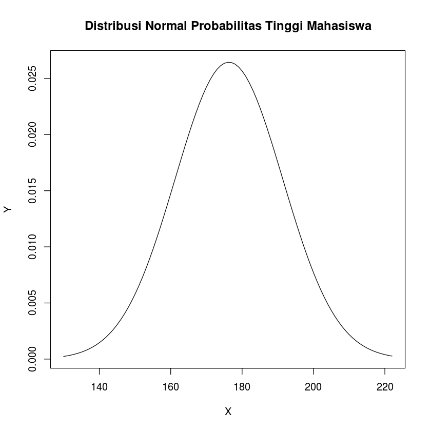

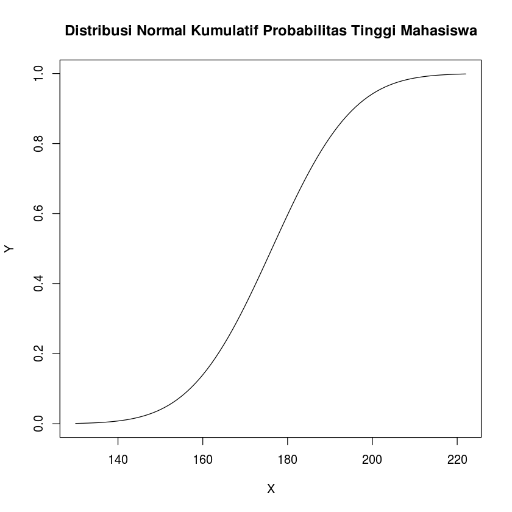

```r
x <- seq(floor(ds$min),ceiling(ds$max))
y <- dnorm(x, mean = ds$mean, ds$sd)
plot(x, y, "l", main = "Distribusi Normal Probabilitas Tinggi Mahasiswa", xlab = "X", ylab = "Y")

y <- pnorm(x, mean = ds$mean, ds$sd)
plot(x, y, "l", main = "Distribusi Normal Kumulatif Probabilitas Tinggi Mahasiswa", xlab = "X", ylab = "Y")
```

### 1.4

```r
"Dibawah 150cm"
pnorm(150.00, mean = ds$mean, ds$sd) * 100
"Diatas 200cm"
100 - pnorm(200.00, mean = ds$mean, ds$sd) * 100
```

'Dibawah 150cm'

4.0555182032133

'Diatas 200cm'

5.81051799655776

### 1.5

```r
"Diantara 160.00cm dan 190.00cm inklusif"
(pnorm(190.00, mean = ds$mean, ds$sd)-pnorm(160.00, mean = ds$mean, ds$sd)) * 50
"170.00cm"
dnorm(170.00, mean = ds$mean, ds$sd) * 50
```

'Diantara 160.00cm dan 190.00cm inklusif'

33.9113691746811

'170.00cm'

1.21181029289386

## Nomor 2

### 2.1

```r
data <- read.csv("datasets/commentlength.csv", header=FALSE)$V1
ds$mean = mean(data)
ds$median = median(data)
ds$modus = getMode(data)
ds$sd = sd(data)
ds$var = var(data)
ds$max = max(data)
ds$min = min(data)
ds$range = ds$max-ds$min
ds

# arr <- rlnorm(1000, log(5), log(3))
# mean(arr)
# max(arr)
# min(arr)
# getMode(ceiling(arr))
# ceiling(arr)
```

| mean | median | modus | sd | var | range | max | min |
| --- | --- | --- | --- | --- | --- | --- | --- |
| 9.585 | 5 | 2 | 15.58903 | 243.0178 | 207 | 208 | 1 |

### 2.2

Distribusi lognormal

Klo jawab dist gamma dibolehin jg, utk kunci jawaban yg dist gamma liat jawaban punya Ellen - T1-IF2122-13516007

### 2.3

2.74656733101476

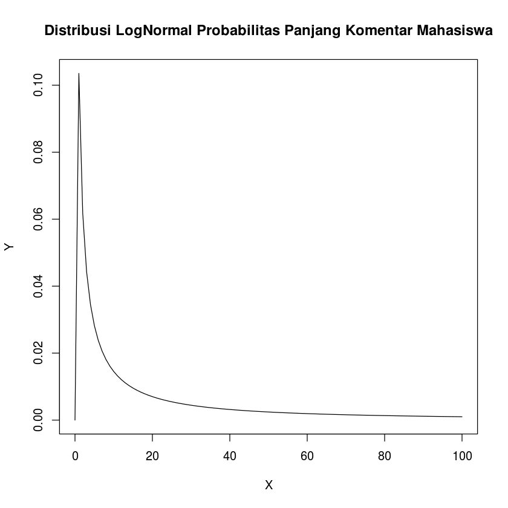

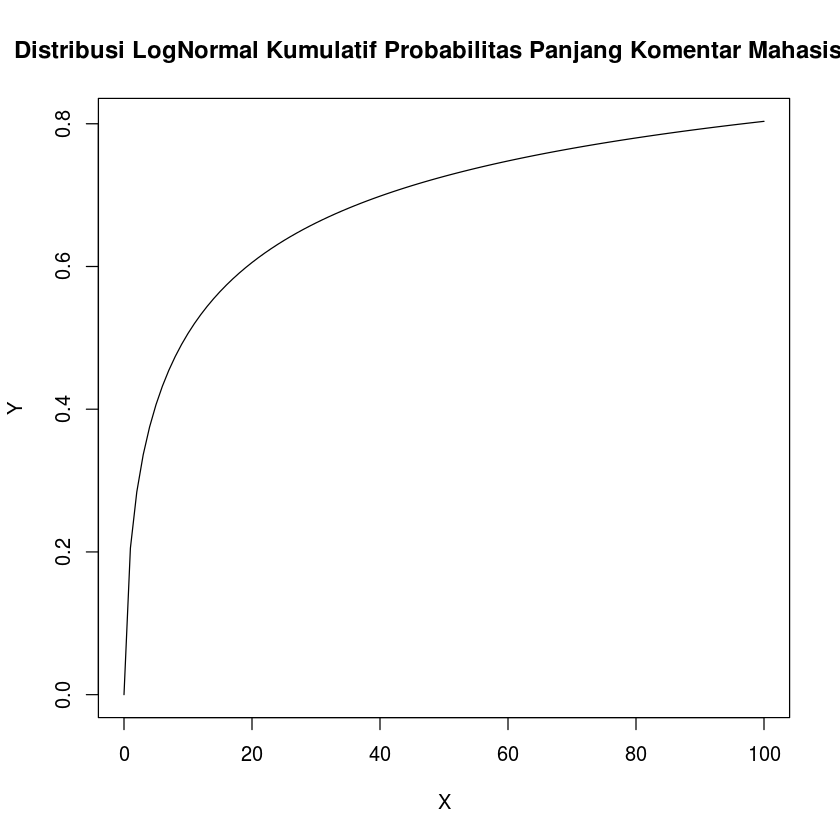

```r
x <- seq(0,100)
log(ds$sd)
y <- dlnorm(x, log(ds$mean), log(ds$sd))
plot(x, y, "l", main = "Distribusi LogNormal Probabilitas Panjang Komentar Mahasiswa", xlab = "X", ylab = "Y")

y <- plnorm(x, log(ds$mean), log(ds$sd))
plot(x, y, "l", main = "Distribusi LogNormal Kumulatif Probabilitas Panjang Komentar Mahasiswa", xlab = "X", ylab = "Y")
```

### 2.4

```r
"Dibawah 3 kata"
plnorm(3, log(ds$mean), log(ds$sd)) * 100
"Diatas 50 kata"
100 - plnorm(50, log(ds$mean), log(ds$sd)) * 100
```

'Dibawah 3 kata'

33.6175641972313

'Diatas 50 kata'

27.3782188550294

### 2.5

```r
"Diantara 4 dan 6 kata inklusif"
(plnorm(6, log(ds$mean), log(ds$sd))-plnorm(4, log(ds$mean), log(ds$sd))) * 200
"1 kata"
dlnorm(1, log(ds$mean), log(ds$sd)) * 200
```

'Diantara 4 dan 6 kata inklusif'

11.4226148104427

'1 kata'

20.706134782642

## Nomor 3

## 3.1

```r
data <- read.csv("datasets/ujian.csv", header=FALSE)$V1
ds$mean = mean(data)
ds$median = median(data)
ds$modus = getMode(data)
ds$sd = sd(data)
ds$var = var(data)
ds$max = max(data)
ds$min = min(data)
ds$range = ds$max-ds$min
ds

nsucc = sum(data >= 75)
nfail = sum(data < 75)
n = nsucc + nfail
pl$psucc = nsucc / n
pl$pfail = nfail / n
pl
n
```

| mean | median | modus | sd | var | range | max | min |
| --- | --- | --- | --- | --- | --- | --- | --- |
| 58.995 | 65 | 76 | 30.93108 | 956.7317 | 100 | 100 | 0 |

| psucc | pfail |
| --- | --- |
| 0.45 | 0.55 |

1000

### 3.2.a

Distribusi Binomial karena ada kejadian sukses dan gagal

### 3.2.b

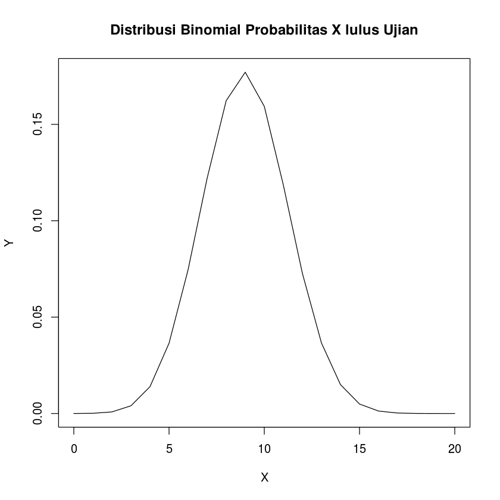

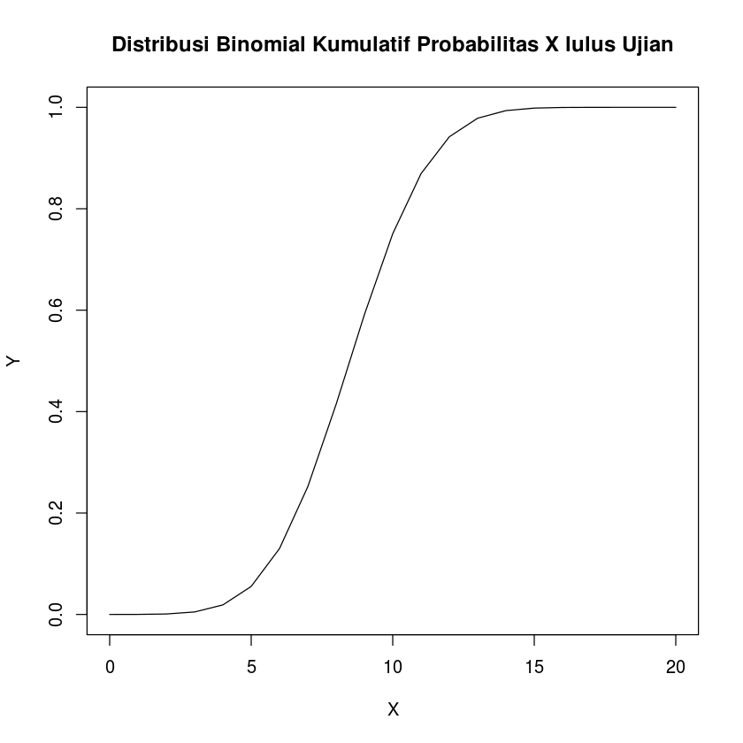

```r
n <- 20
x <- seq(0, n)
y <- dbinom(x, n, pl$psucc)
plot(x, y, "l", main = "Distribusi Binomial Probabilitas X lulus Ujian", xlab = "X", ylab = "Y")

y <- pbinom(x, n, pl$psucc)
plot(x, y, "l", main = "Distribusi Binomial Kumulatif Probabilitas X lulus Ujian", xlab = "X", ylab = "Y")
```

### 3.2.c

```r
"minimal X lulus sebanyak 8 kali P(X>=8) succ"
1 - pbinom(8, n, pl$psucc)
```

0.585693765883884

### 3.2.d

```r
"maksimal X tidak lulus sebanyak 10 kali P(X<=10) fail"
pbinom(10, n, pl$pfail)
```

'maksimal X tidak lulus sebanyak 10 kali P(X<=10) fail'

0.408638815328372

### 3.3.a

Distribusi geometri karena dicoba terus2an sampai berhasil sekali

### 3.3.b

[figure not shown]

[figure not shown]

```r
x <- seq(0, 50)
y <- dgeom(x, pl$psucc)
plot(x, y, "l", main = "Distribusi Binomial Probabilitas X lulus Ujian", xlab = "X", ylab = "Y")

y <- pgeom(x, pl$psucc)
plot(x, y, "l", main = "Distribusi Binomial Kumulatif Probabilitas X lulus Ujian", xlab = "X", ylab = "Y")
```

### 3.3.c

```r
"peluang X lulus setelah menyelesaikan ujian ke-10"
dgeom(9, pl$psucc) # 9 kali gagal
pl$psucc^1*pl$pfail^9
```

'peluang X lulus setelah menyelesaikan ujian ke-10'

0.00207241496279297

0.00207241496279297

### 3.3.d

```r
"peluang X lulus setelah menyelesaikan ujian ke-4 atau ke-6"
dgeom(3, pl$psucc) + dgeom(5, pl$psucc)
```

'peluang X lulus setelah menyelesaikan ujian ke-4 atau ke-6'

0.097516546875

### 3.3.e

```r
"peluang X lulus apabila hanya diberi 3 kali kesempatan"
pgeom(2, pl$psucc)
```

'peluang X lulus apabila hanya diberi 3 kali kesempatan'

0.833625

### 3.3.f

```r
"peluang X lulus setelah menyelesaikan ujian pertama"
dgeom(0, pl$psucc)
```

'peluang X lulus setelah menyelesaikan ujian pertama'

0.45

## Nomor 4

### 4.1

```r
data <- read.csv("datasets/kejahatan.csv", header=TRUE)$jumlah_kejahatan

ds$mean = mean(data)
ds$median = median(data)
ds$modus = getMode(data)
ds$sd = sd(data)
ds$var = var(data)
ds$max = max(data)
ds$min = min(data)
ds$range = ds$max-ds$min
ds
```

| mean | median | modus | sd | var | range | max | min |
| --- | --- | --- | --- | --- | --- | --- | --- |
| 0.0456621 | 0 | 0 | 0.2766291 | 0.07652367 | 4 | 4 | 0 |

### 4.2

Poisson

### 4.3

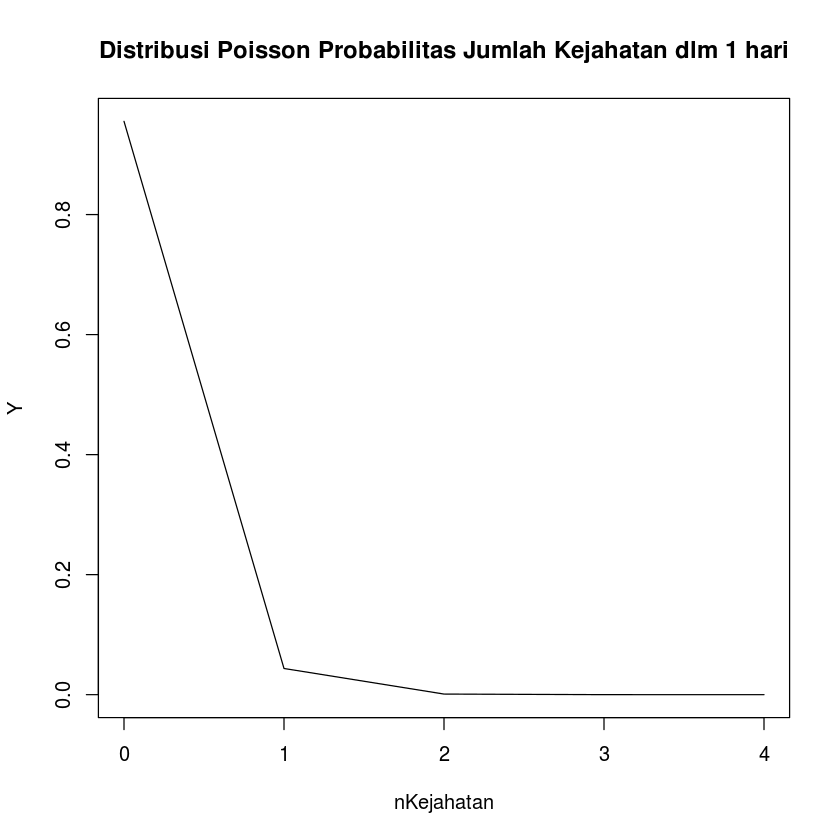

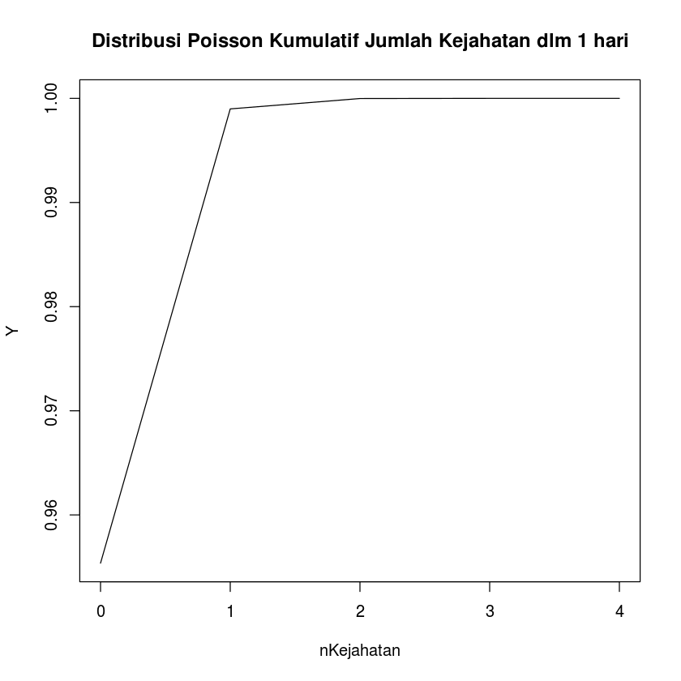

```r
x <- seq(ds$min, ds$max)
y <- dpois(x, ds$mean)
plot(x, y, "l", main = "Distribusi Poisson Probabilitas Jumlah Kejahatan dlm 1 hari", xlab = "nKejahatan", ylab = "Y")

y <- ppois(x, ds$mean)
plot(x, y, "l", main = "Distribusi Poisson Kumulatif Jumlah Kejahatan dlm 1 hari", xlab = "nKejahatan", ylab = "Y")
```

### 4.4

```r
"4.4a"
dpois(0, ds$mean*30)
"4.4b"
ppois(20, ds$mean*365)
```

'4.4a'

0.254141771109641

'4.4b'

0.827840045337825

### 4.5

```r
dpois(10, ds$mean*365)
"jd hasilnya 10 wkakaka"
```

0.0263319546361829

'jd hasilnya 10 wkakaka'